# Proyección de la magnitud de sismos para Antioquia

#### Febrero de 2018

##### Realizado por:

- **Nestor Jardany Serrano Rojas**, [GitHub](https://github.com/jardanys/GeoEstadistica_Sismos)
- **Camilo Alejandro Aguilar Laverde**, [GitHub](https://github.com/CamiloAguilar/GeoEstadistica_Sismos)
- **Alvaro Enrique Villaba Mendez**, [GitHub](https://github.com/AlvaroVillalba/GeoEstadistica_Sismos)

## Introducción

El *objetivo* del presente estudio consiste en utilizar información histórica sobre la actividad sísmica en el departamento de Antioquia en Colombia, para estimar por rangos, la posible intensidad actividad sísmica en las zonas donde no se presentaron movimientos.

- Se observaron descriptivamente los datos.
- Se comprobo estacionariedad. La magnitud local en escala de Richter presenta estacionariedad en los datos y no fue necesario modelar tendencia. La media es constante sobre la región de observación.
- Se modela la dependencia espacial de la varianza por medio de un modelo exponencial.
- Se utiliza validación cruzada para determinar el mejor modelo de la varianza. Un modelo de mínimos cuadrados generalizados.
- Se realiza interpolación por tres métodos.

## Descripción de los datos

La información utilizada en el presente documento fue tomada de la [Red Sismológica Nacional de Colombia](http://200.119.88.135/RSNC/), en su *BOLETÍN PRELIMINAR DE EVENTO SÍSMICO*. Dichos datos contienen toda la actividad sísmica del departamento de Antioquia, durante el mes de Junio de 2017 y en total dicha información contiene 123 observaciones. La siguiente tabla contiene una muestra con las primeras 6 observaciones:

| Magnitud.Ml | Longitud | Latitud | Municipio | Profundidad.Km |
| --- | --- | --- | --- | --- |
| 1.3 | -76.035 | 5.860 | CIUDAD BOLIVAR | 56.0 |
| 1.3 | -74.715 | 6.536 | MACEO | 14.6 |
| 1.5 | -74.860 | 5.870 | SAN LUIS | 4.7 |
| 1.3 | -76.212 | 7.182 | DABEIBA | 0.0 |
| 1.9 | -77.071 | 6.863 | VIGIA DEL FUERTE | 18.0 |
| 1.2 | -74.843 | 6.694 | YALI | 51.3 |

<sup>1</sup> Actividad Sismica escala de Richter

A continuación se muestra un análisis descriptivo de los datos, los cuales muestran visualmente un comportamiento que sigue una distribución normal, por lo que se ha decidido que no es necesario realizar alguna transformación a los datos.

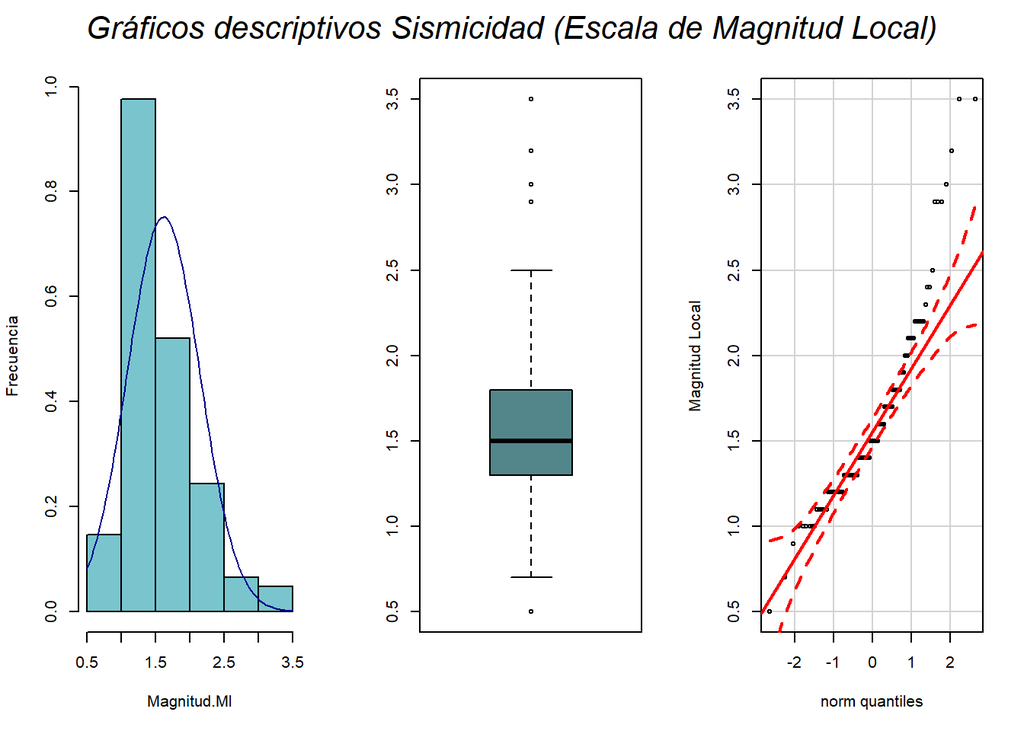

```r
par(mfrow = c(1, 3))
hist(datosdf$Magnitud.Ml, freq = FALSE, main = "", xlab = "Magnitud.Ml", ylab = "Frecuencia",
     col="cadetblue3")
curve(dnorm(x, mean(datosdf$Magnitud.Ml), sd(datosdf$Magnitud.Ml)), add = T, col="darkblue")
boxplot(datosdf$Magnitud.Ml, col="cadetblue4")
qqPlot(datosdf$Magnitud.Ml, ylab = "Magnitud Local")
title(main=list("Gráficos descriptivos Sismicidad (Escala de Magnitud Local)",cex=2,col="black", font=3), outer=T,line=-2)
```

El siguiente mapa espacial muestra la actividad sismica en el departamento de Antioquia. Se observa que la zona occidental presenta una mayor actividad frente a la zona centro, donde la actividad es casi nula. La magnitud más fuerte es de $3.5$ en la escala de Ricther, la cual se presentó en el municipio de *Taraza* el día 13 de junio, a una profundidad de $42.5$ Km.

[interactive chart not shown]

## Análisis de Estacionariedad

Se realizan los gráficos de la variable *Magnitud en escala de Richter* contra las direcciones (Longitud, Latitud). Se observan con cierta estacionariedad y sin tendencia significativa. En los gráficos la media de la maginitud local se observa constante sobre la región de observación, por tanto no resulta necesario remover alguna dependencia.

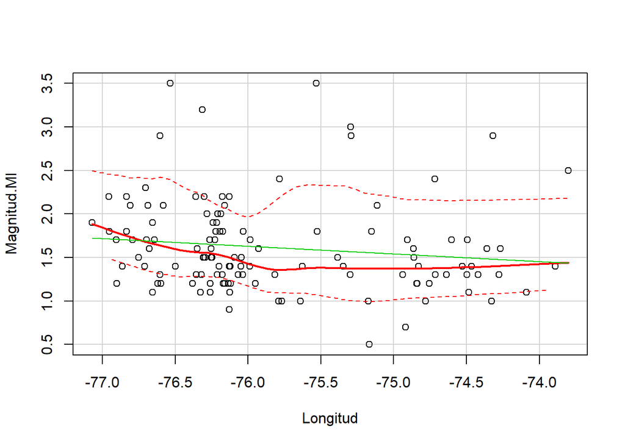

```r
scatterplot(Magnitud.Ml~Longitud, reg.line=lm, smooth=TRUE, spread=TRUE, boxplots=FALSE, span=0.5, data=datosdf)
```

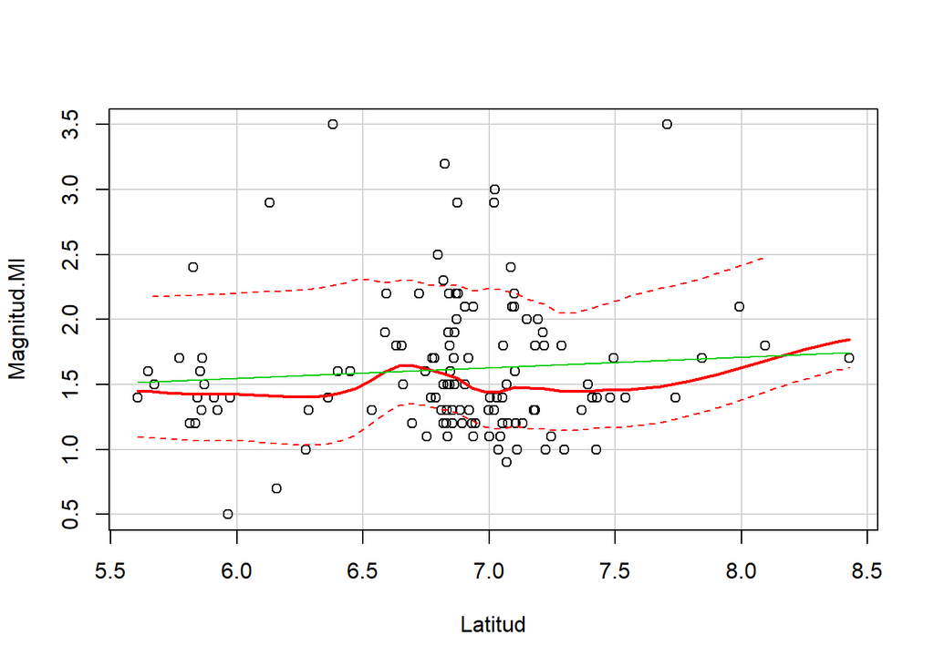

```r
scatterplot(Magnitud.Ml~Latitud, reg.line=lm, smooth=TRUE, spread=TRUE, boxplots=FALSE, span=0.5, data=datosdf)
```

A continuación se ajusta un modelo de la Magnitud Local en función de la Lat y Long. Se modela en términos de las direcciones y se utilizó un modelo cuadrático en las direcciones con un stepwise. Como se observa la magnitud no depende de las coordenadas y el proceso es estacionario.

```r
modelo1 = lm(Magnitud.Ml ~ Longitud + Latitud + I(Longitud * Latitud) + I(Longitud^2)
             + I(Latitud^2), data = datosdf)
summary(modelo1)
```

```
##
## Call:
## lm(formula = Magnitud.Ml ~ Longitud + Latitud + I(Longitud *
##     Latitud) + I(Longitud^2) + I(Latitud^2), data = datosdf)
##
## Residuals:
##     Min      1Q  Median      3Q     Max
## -0.9633 -0.3305 -0.1272  0.1979  1.9024
##
## Coefficients:
##                        Estimate Std. Error t value Pr(>|t|)
## (Intercept)           616.29119  460.74205   1.338    0.184
## Longitud               16.19471   12.15279   1.333    0.185
## Latitud                -1.99117    9.67349  -0.206    0.837
## I(Longitud * Latitud)  -0.01664    0.13101  -0.127    0.899
## I(Longitud^2)           0.10704    0.08076   1.325    0.188
## I(Latitud^2)            0.05880    0.11859   0.496    0.621
##
## Residual standard error: 0.5313 on 117 degrees of freedom
## Multiple R-squared:  0.03809,    Adjusted R-squared:  -0.003012
## F-statistic: 0.9267 on 5 and 117 DF,  p-value: 0.4664
```

```r
# step(modelo1)
```

## Análisis a sentimiento

La primer etapa en el desarrollo de un análisis geoestadístico, es la determinación de la dependencia espacial entre los datos medidos de una variable. Para esto hacemos uso del semivariograma sobre las magnitud de los sismos. Previo a su aplicación, es necesario convertir los datos a un objeto de clase **geodata**. Controlamos además la presencia de ubicaciones duplicadas.

```r
datos2 <- data.frame(Longitud = datosdf$Longitud, Latitud = datosdf$Latitud, res = datosdf$Magnitud.Ml)
geo = as.geodata(datos2, coords.col = 1:2, data.col = 3)
class(geo)
```

```
## [1] "geodata"
```

```r
dup.coords(geo) # No hay duplicados
```

Graficamos finalmente el variograma, donde se puede apreciar que existe una relación de dependencia espacial entre las diferentes observaciones.

```r
# Estimación del variograma
var <- variog(geo, max.dist = 1.5, direction = "omnidirectional")
```

```
## variog: computing omnidirectional variogram
```

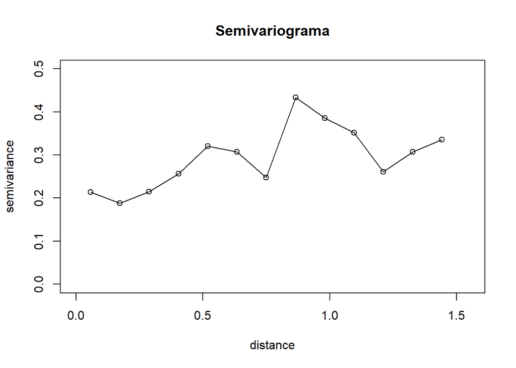

```r
plot(var, main="Semivariograma", xlim=c(0, 1.55), type="o", ylim=c(0,0.5))
```

De acuerdo con lo anterior resulta necesario definir un modelo que describa dicha estructura de dependencia, lo que nos permitirá mas adelante realizar estimaciones en puntos donde no se presentaron aún sismos. Para ello resulta conveniente utilizar un modelo paramétrico inicial con estructura exponencial, asignando a sentimiento las siguientes caracteristicas iniciales:

```r
ev
```

```
##     cov.model           sigmasq               phi              tausq kappa
## 1 exponential 0.347213296398892 0.480764636730187 0.0434016620498615  <NA>
##   kappa2   practicalRange
## 1   <NA> 1.44026987390761
```

Este modelo inicial servirá de base para realizar un ajuste computacional de mayor precisión. Se ajustan los siguientes 3 modelos:

- mod1 -> Valores iniciales. **equal**.
- mod2 -> Mínimos Cuadrados Ponderados. **npairs**.
- mod3 -> Mínimos Cuadrados Ponderados. **cressie**.

```r
#Asignando valores iniciales
mod1 <- variofit(var, ini=ev, weights="equal")
```

```
## variofit: covariance model used is exponential
## variofit: weights used: equal
## variofit: minimisation function used: optim
```

```r
#Minimos cuadrados ponderados
mod2 <- variofit(var, ini=ev, weights="npairs")
```

```
## variofit: covariance model used is exponential
## variofit: weights used: npairs
## variofit: minimisation function used: optim
```

```r
#Minimos cuadrados ponderados
mod3 <- variofit(var, ini=ev, weights="cressie")
```

```
## variofit: covariance model used is exponential
## variofit: weights used: cressie
## variofit: minimisation function used: optim
```

La siguiente gráfica muestra el contraste sobre el ajuste de los diferentes modelos anteriormente especificados conestructura exponencial:

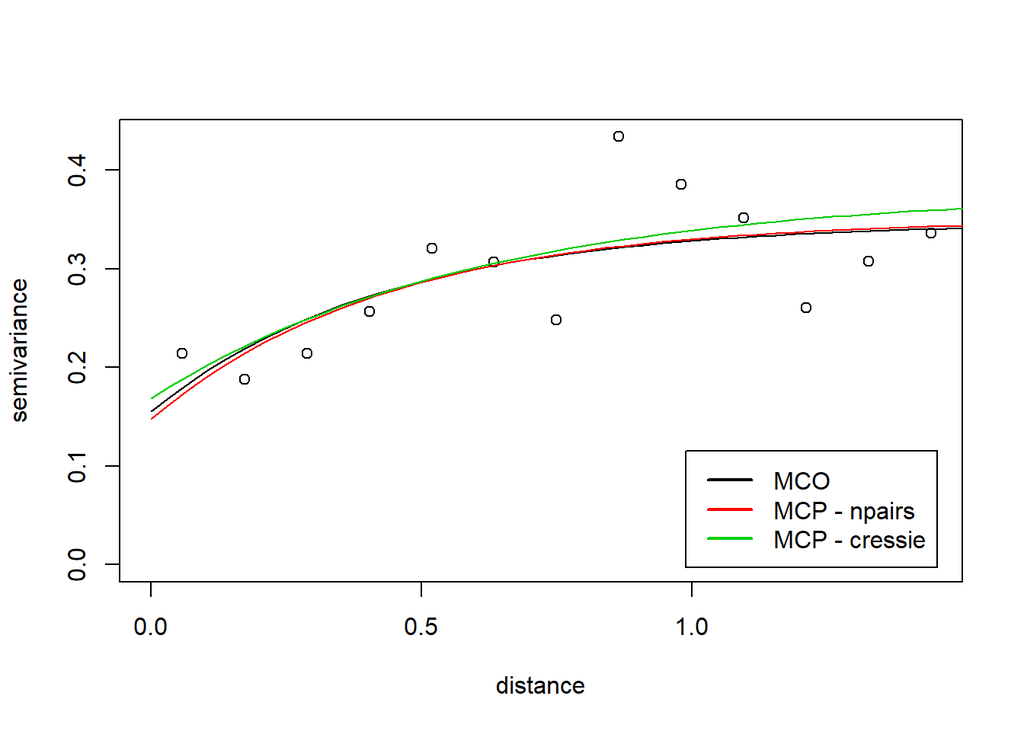

```r
plot(var)
lines(mod1, max.dist = 3.5, col = 1)
lines(mod2, max.dist = 3.5, col = 2)
lines(mod3, max.dist = 3.5, col = 3)

legend("bottomright",legend = c("MCO", "MCP - npairs", "MCP - cressie"),
       col = 1:5, lwd = 2, inset = .03)
```

## Validación Cruzada

La validación cruzada es una técnica utilizada para evaluar los resultados de un análisis estadístico. Aquí cada ubicación asociada a los sismos se elimina del conjunto de datos y la variable en esta ubicación se predice usando las ubicaciones restantes, utilizando cada modelo ajustado anteriormente. Observamos que el modelo 3 presenta entonces un mejor ajuste.

```r
sqrt(mean(cruzada1$error^2))
```

```
## [1] 0.5589772
```

```r
sqrt(mean(cruzada2$error^2))
```

```
## [1] 0.5611737
```

```r
sqrt(mean(cruzada3$error^2))
```

```
## [1] 0.5536069
```

## Interpolación

Para el proceso de interpolación, se ha decidido tomar una muestra regular de **10,000** puntos dentro del poligono del departamento de antioquia, los cuales se observan a continuación:

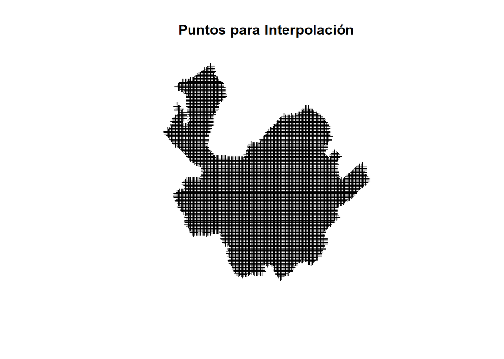

### Kriging Universal

Se utiliza el método de **Kriging Universal** para predecir dentro del territorio de Antioquia las intensidades sísmicas de mayor probabilidad en caso que allí se presentara un evento, tomando una función cuadratica de las distancias.

```r
krig_u <- krige(Magnitud.Ml ~ Longitud + I(Longitud * Latitud) + I(Longitud^2) + I(Latitud^2), datossp, muestra1, model = mod1_1)
```

```
## [using universal kriging]
```

Como se puede observar en las sigueintes graficas, la varianza no resulta ser muy alta y no presenta islas, la zona sur occidental de departamento es más propensa a tener actividad sismica con mayor nivel de magnitud y la zona sur oriental es la de menor actividad.

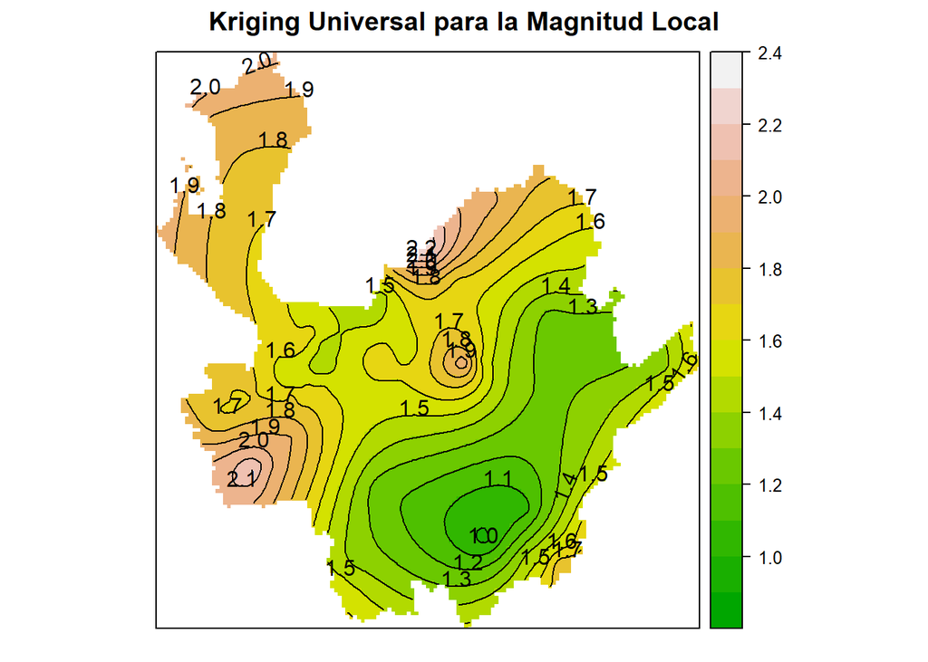

```r
spplot(krig_u, c("var1.pred"), main = "Kriging Universal para la Magnitud Local", contour = T,
       labels = T, pretty = TRUE, col = "black", col.regions = terrain.colors(100))
```

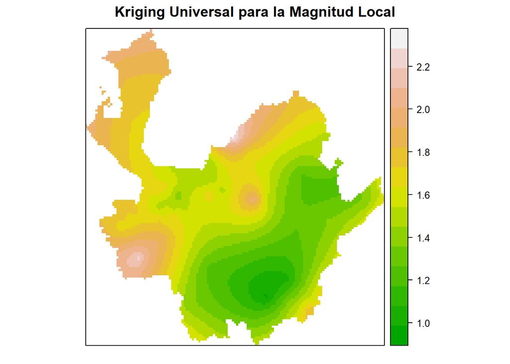

```r
spplot(krig_u, c("var1.pred"), main = "Kriging Universal para la Magnitud Local", contour = FALSE,
       labels = FALSE, pretty = F, col = "black", col.regions = terrain.colors(100))
```

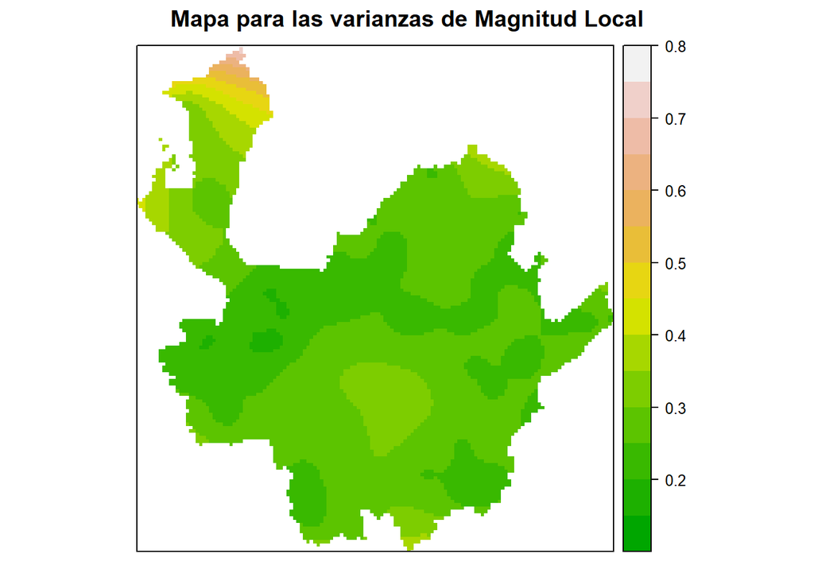

```r
spplot(krig_u, c("var1.var"), main = "Mapa para las varianzas de Magnitud Local", contour = FALSE,
       labels = FALSE, pretty = TRUE, col = "black", col.regions = terrain.colors(100))
```

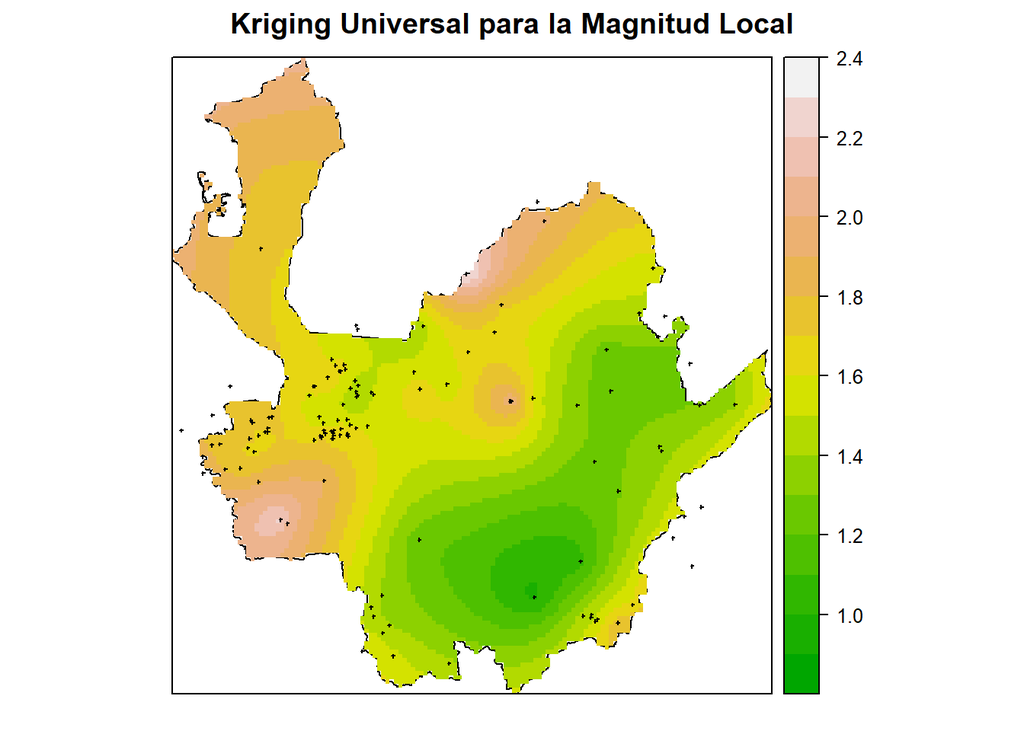

```r
li = list("sp.polygons", Antioquia)
pts = list("sp.points", datossp, pch = 3, col = "black", cex = 0.2)
spplot(krig_u, c("var1.pred"), main = "Kriging Universal para la Magnitud Local",
       sp.layout = list(li, pts), contour = FALSE, labels = FALSE, pretty = TRUE, col = "black",
       col.regions = terrain.colors(100))
```

### Kriging ordinario

```r
krig_ord <- krige(Magnitud.Ml ~ 1, datossp, muestra1, model = mod1_1)
```

```
## [using ordinary kriging]
```

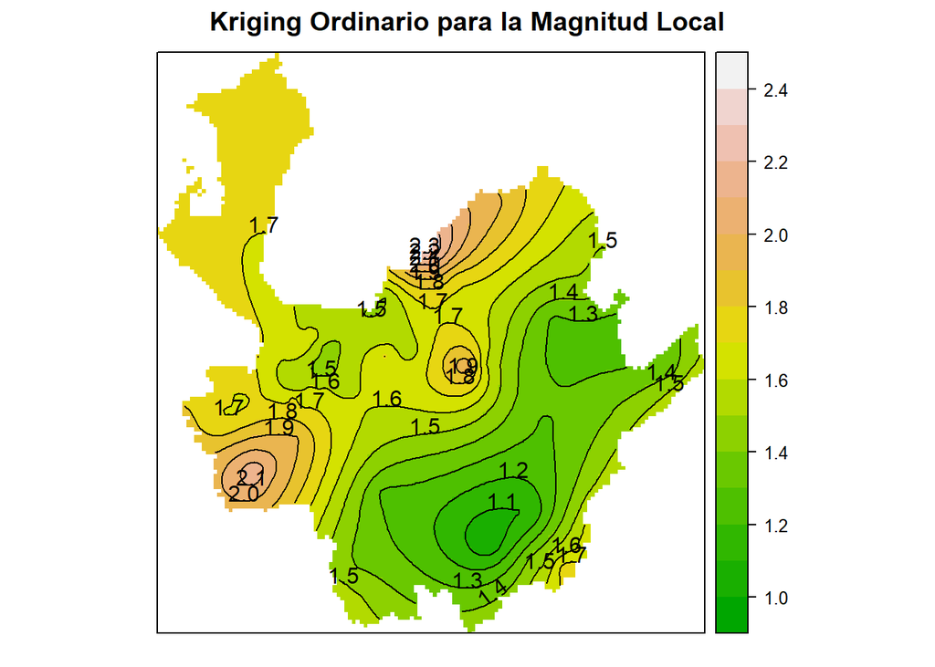

```r
spplot(krig_ord, c("var1.pred"), main = "Kriging Ordinario para la Magnitud Local", contour = T,
       labels = T, pretty = TRUE, col = "black", col.regions = terrain.colors(100))
```

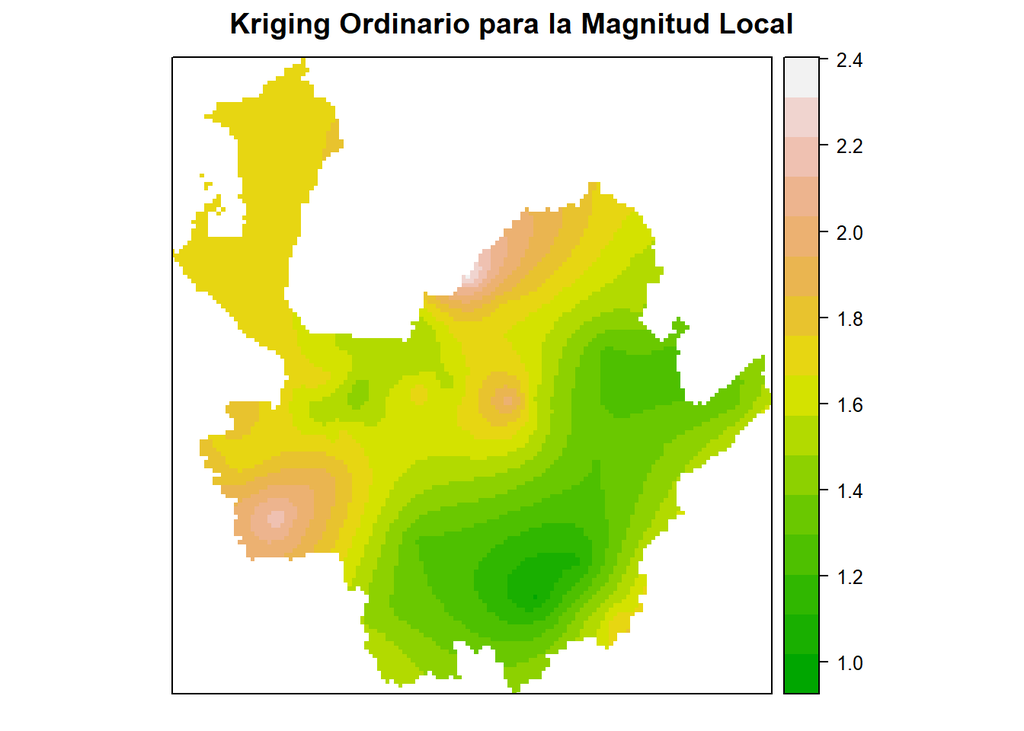

```r
spplot(krig_ord, c("var1.pred"), main = "Kriging Ordinario para la Magnitud Local", contour = FALSE,
       labels = FALSE, pretty = F, col = "black", col.regions = terrain.colors(100))
```

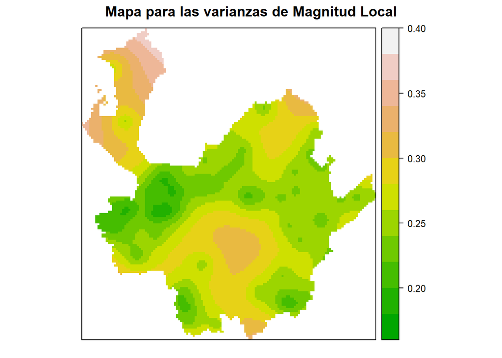

```r
spplot(krig_ord, c("var1.var"), main = "Mapa para las varianzas de Magnitud Local", contour = FALSE,
       labels = FALSE, pretty = TRUE, col = "black", col.regions = terrain.colors(100))
```

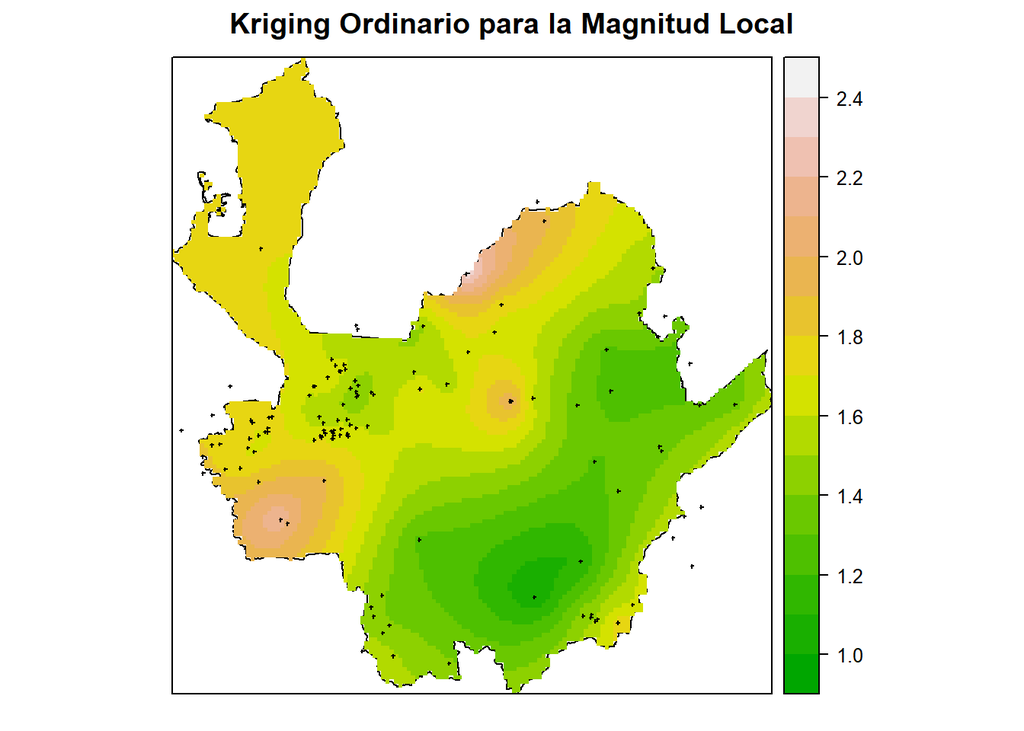

```r
li = list("sp.polygons", Antioquia)
pts = list("sp.points", datossp, pch = 3, col = "black", cex = 0.2)
spplot(krig_ord, c("var1.pred"), main = "Kriging Ordinario para la Magnitud Local",
       sp.layout = list(li, pts), contour = FALSE, labels = FALSE, pretty = TRUE, col = "black",
       col.regions = terrain.colors(100))
```

### No-geoestadístico thiessen

```r
thiessen = krige(Magnitud.Ml ~ 1, datossp, muestra1, nmax = 4)
```

```
## [inverse distance weighted interpolation]
```

Como se peude observar la varianza es muy alta y presenta islas, la zona sur oriental de departamento presenta una mayor varianza.

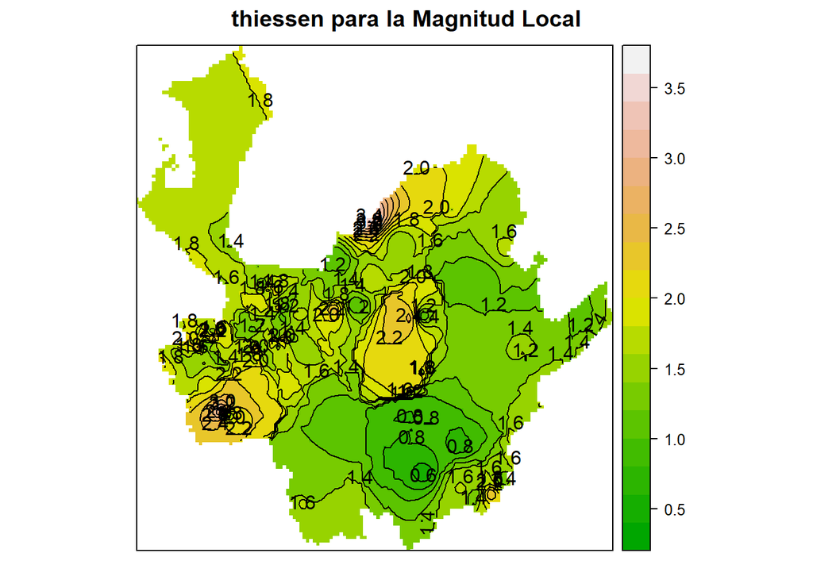

```r
spplot(thiessen, c("var1.pred"), main = "thiessen para la Magnitud Local", contour = T, labels = T,
       pretty = TRUE, col = "black", col.regions = terrain.colors(100))
```

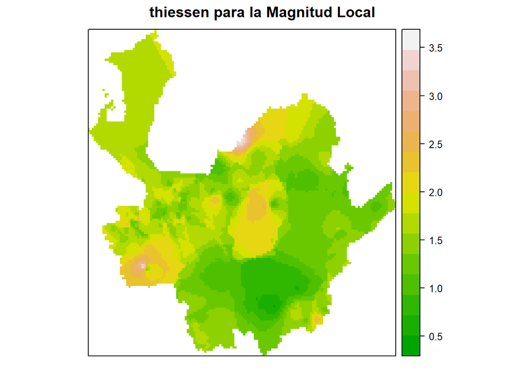

```r
spplot(thiessen, c("var1.pred"), main = "thiessen para la Magnitud Local", contour = FALSE, labels = FALSE,
       pretty = F, col = "black", col.regions = terrain.colors(100))
```

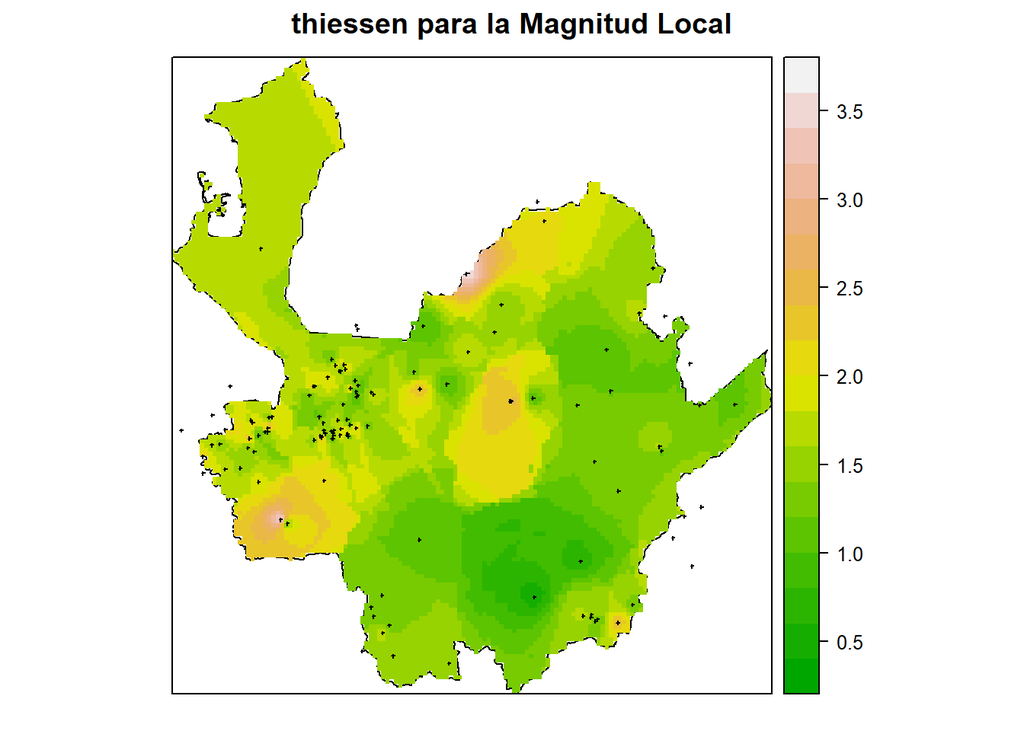

```r
li = list("sp.polygons", Antioquia)
pts = list("sp.points", datossp, pch = 3, col = "black", cex = 0.2)
spplot(thiessen, c("var1.pred"), main = "thiessen para la Magnitud Local", sp.layout = list(li, pts),
       contour = FALSE, labels = FALSE, pretty = TRUE, col = "black", col.regions = terrain.colors(100))
```

## Conclusiones

- Se observaron descriptivamente los datos.
- Se comprobó estacionariedad. La magnitud local en escala de Richter presenta estacionariedad en los datos y no fue necesario modelar tendencia. La media es constante sobre la región de observación.
- Se modeló la dependencia espacial de la varianza por medio de un modelo exponencial con los parámetros expuestos en el estudio.
- Se utilizó validación cruzada para determinar el mejor modelo de la varianza. El resultado evidenció en este caso que el modelo ajustado bajo mínimos cuadrados generalizados arrojó el mejor resultado.
- Se realizaron predicciones sobre la interpolación propuesta, bajo tres métodos. El mejor ajuste resultó ser el de **Kriging Universal**.
- La zona sur occidental de departamento resulta ser más propensa a eventos de mayor intensidad sísmica, en caso que se presentara un evento. La zona sur oriental resultaría la de menor intensidad o magnitud de sus eventos.

2018-02 Realizado por: Camilo Aguilar - Nestor Serrano - Alvaro VIllalba

Copyright © All rights reserved.